# To which food group does a product of OpenFoodFacts belong ?

Mehdi Miah (mehdi.miah@gmail.com)

08-11-2018

**Abstract** : Given a product of OpenFoodFacts’s database, this notebook predicts in which food group it belongs to. The algorithm relies on a (un-optimized) decision tree and six features : the mass of sugar, carbohydrate (= glucide in French), salt, proteins, fat and saturated fat in 100g of food. Firstly, some statistics and data visualization are shown in order to prove that this methodology may work, then a decision tree is fitted with the data. Finally, this approch enables to predict for 3 out of 4 products the food group with an accuracy of 70%.

# Setup

```r
# Remove all variables
rm(list = ls())

# Libraries
library(data.table) #to read (fread) databases
library(knitr) #for notebook
library(ggplot2) #for dataviz
library(ggrepel) #for labeling points nicely
library(rpart) #for decision tree
library(rpart.plot) #to plot decision tree
library(tidyr) #to handle dataframes
library(dplyr) #to handle dataframes
```

# Opening the file

```r
# Opening the file
na_strings = c(NA, "NA", "") #values considered as missing values
openfoodfacts = fread("../data/openfoodfacts/intermediate/openfoodfacts.csv", sep = ";", stringsAsFactors = FALSE, data.table = FALSE, encoding = "UTF-8", na.strings = na_strings)

# Structure of the file
str(openfoodfacts)
```

```
## 'data.frame':    677830 obs. of  23 variables:
##  $ EAN                : chr  "0000000000017" "0000000000031" "0000000000123" "0000000000291" ...
##  $ product_name       : chr  "Vitória crackers" "Cacao" "Sauce Sweety chili 0%" "Mendiants" ...
##  $ quantity           : chr  NA "130 g" NA NA ...
##  $ countries_fr       : chr  "France" "France" "France" "France" ...
##  $ serving_size       : chr  NA NA NA NA ...
##  $ serving_quantity   : num  0 0 0 0 0 0 NA 0 0 0 ...
##  $ nutriscore         : chr  NA NA NA NA ...
##  $ pnns_groups_2      : chr  NA NA NA NA ...
##  $ energy_100g        : num  1569 NA 88 NA 134 ...
##  $ glucides_100g      : num  70.1 NA 4.8 NA 5.3 16.3 NA NA 38.4 41 ...
##  $ fat_100g           : num  7 NA 0 NA 0.3 4.9 NA NA 3.3 9.4 ...
##  $ saturatedFat_100g  : num  3.08 NA 0 NA 0.1 3.1 NA NA 2.1 4.5 ...
##  $ transFat_100g      : num  NA NA NA NA NA NA NA NA NA NA ...
##  $ sugars_100g        : num  15 NA 0.4 NA 3.9 16.3 NA NA 1.8 2 ...
##  $ fiber_100g         : num  NA NA NA NA NA NA NA NA NA NA ...
##  $ proteins_100g      : num  7.8 NA 0.2 NA 0.9 4.4 NA NA 11.7 12.5 ...
##  $ salt_100g          : num  1.4 NA 2.04 NA 0.42 0.25 NA NA 0.678 0.9 ...
##  $ vitaminA_100g      : num  NA NA NA NA NA NA NA NA NA NA ...
##  $ vitaminC_100g      : num  NA NA NA NA NA NA NA NA NA NA ...
##  $ calcium_100g       : num  NA NA NA NA NA NA NA NA NA NA ...
##  $ iron_100g          : num  NA NA NA NA NA NA NA NA NA NA ...
##  $ score_nutritif_100g: int  NA NA NA NA NA NA NA NA NA NA ...
##  $ groupe_1           : chr  NA NA NA NA ...
```

# How to classify foods ?

The goal of the project is to generate balanced meals. One definition of a balanced meal is proposed in the article “recommandations-pour-un-colis-d-aide-alimentaire-equilibre_doc” (cf Slack). The perfect meal is the one below :

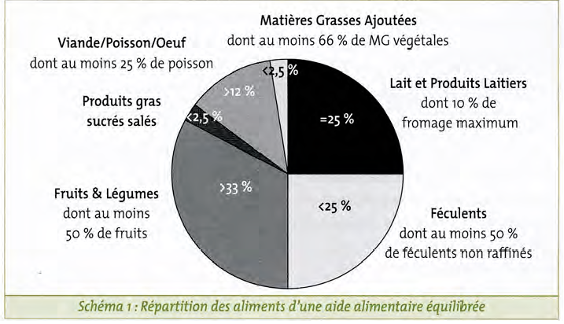

Is there any variable in the Open Food Facts’s database which is close of the main groups ? Yes, there is hopefully one : “groupe_1”

Let’s see the values taken by this variable :

```r
# Unique values taken by the variable groupe_1
openfoodfacts$groupe_1 %>% unique() %>% sort()
```

```
## [1] "Beverages"               "Cereals and potatoes"
## [3] "Composite foods"         "Fat and sauces"
## [5] "Fish Meat Eggs"          "Fruits and vegetables"
## [7] "Milk and dairy products" "Salty snacks"
## [9] "Sugary snacks"
```

If one only consideres the main food groups of the chart, one gets the following links with the Open Food Facts’s database :

| Food group in the file | Food group in OpenFoodFacts |
| --- | --- |
| Fruits et légumes | Fruits and vegetables |
| Produits gras, sucrés, salés | Sugary snacks + Salty snacks |
| Viande, poisson, oeuf | Fish, meat, eggs |
| Matières grasses ajoutées | Fat and sauce |
| Lait et produits laitiers | Milk and dairy products |
| Féculents | Cereals and potatoes |
| - | Composite foods + Beverages |

Now, let’s see if this variable is correctly provided in the database.

There are two remained tasks : how to deal with composite foods (salads, pizza, …) and beverages (orange juice, coke, …), and can we get a similar variable for the sub-category fruits, cheese, … ?

# Missing values

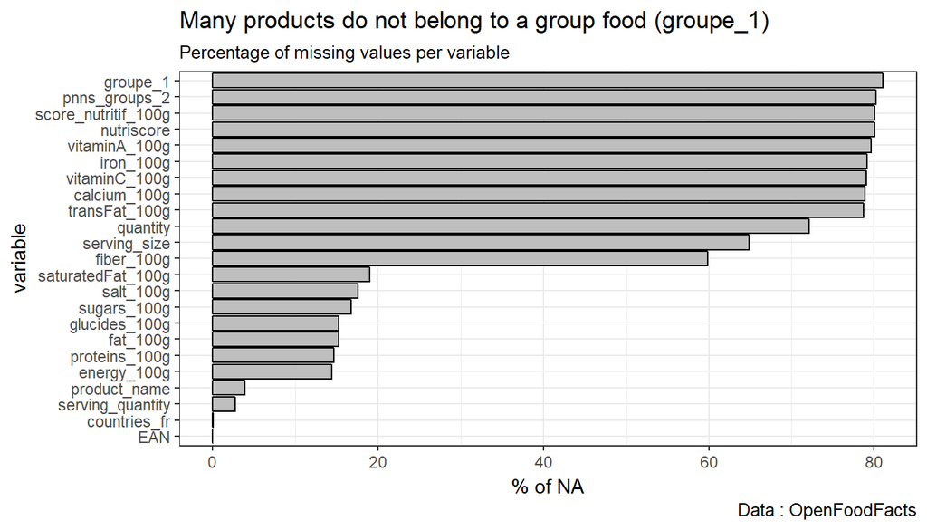

```r
# Percentage of missing values per variable
pct_NA_variable_OFF = (colSums(is.na(openfoodfacts)) / nrow(openfoodfacts) * 100)

# Get a nice dataframe
pct_NA_variable_OFF = pct_NA_variable_OFF %>% as.data.frame()
names(pct_NA_variable_OFF) = c("pct")
pct_NA_variable_OFF$variable = rownames(pct_NA_variable_OFF)

# Sort the variable
pct_NA_variable_OFF$variable = factor(pct_NA_variable_OFF$variable,
                                      levels = pct_NA_variable_OFF$variable[order(pct_NA_variable_OFF$pct)])

# Get a nice visualization
ggplot(pct_NA_variable_OFF, aes(x = variable, y = pct)) +
  geom_bar(stat = "identity", color = "black", fill = "grey") +
  ggtitle(label = "Many products do not belong to a group food (groupe_1)",
          subtitle = "Percentage of missing values per variable") +
  coord_flip() +
  labs(x = "variable",
       y = "% of NA",
       caption = "Data : OpenFoodFacts") +
  theme_bw()
```

Unfortunately, the target variable, groupe_1, is missing in 8 out of 10 products … However, as nutrients (sugar, salt, proteins, fat, saturated fat and carbohydrates) and product’s names are valid in many observations, it seems possible to predict the food group from these inputs. In a matter of simplicity, I will only use nutrients as inputs for a baseline model.

# Some analysis on nutrients

## Distribution of food group in Open Food Facts’s database

```r
# Number of products per food group
n_EAN_by_groupe1 = openfoodfacts %>%
  filter(!is.na(groupe_1)) %>%
  group_by(groupe_1) %>%
  summarise(count = EAN %>% unique() %>% length()) %>%
  ungroup()
```

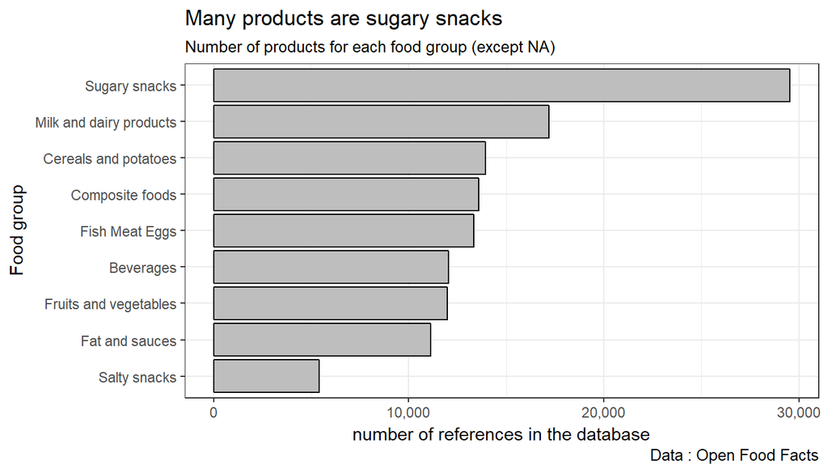

```r
# Sort the groups
n_EAN_by_groupe1$groupe_1 =  factor(n_EAN_by_groupe1$groupe_1,
                                    levels = n_EAN_by_groupe1$groupe_1[order(n_EAN_by_groupe1$count)])


# Visualization
ggplot(n_EAN_by_groupe1, aes(x = groupe_1, y = count)) +
  geom_bar(stat = "identity", color = "black", fill = "grey") +
  ggtitle(label = "Many products are sugary snacks",
          subtitle = "Number of products for each food group (except NA)") +
  labs(x = "Food group",
       y = "number of references in the database",
       caption = "Data : Open Food Facts") +
  scale_y_continuous(labels = scales::comma) +
  coord_flip() +
  theme_bw()
```

From the graph below, it appears that the repartition is not uniform : there are more sugary snacks and dairy products than fruits. One should be careful about possible bias when one will predict the food group.

## Part of missing nutrients per food group

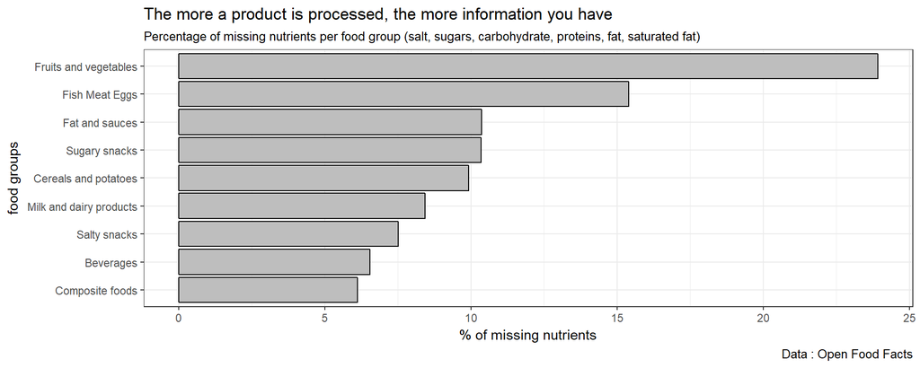

```r
# Percentage of missing nutrients per food group
pct_NA_groupe_1 = openfoodfacts %>%
  filter(!is.na(groupe_1)) %>%
  select(groupe_1, salt_100g, sugars_100g, glucides_100g, fat_100g, proteins_100g, saturatedFat_100g) %>%
  gather("nutriment", "valeur", -groupe_1) %>% #one gets long format thanks to the package tidyr
  group_by(groupe_1) %>%
  summarise(pct_NA = 100 * mean(is.na(valeur))) %>%
  ungroup()

# Sort the food goup
pct_NA_groupe_1$groupe_1 = factor(pct_NA_groupe_1$groupe_1,
                                  levels = pct_NA_groupe_1$groupe_1[order(pct_NA_groupe_1$pct_NA)])

# Visualization
ggplot(pct_NA_groupe_1, aes(x = groupe_1, y = pct_NA)) +
  geom_bar(stat = 'identity', color = "black", fill = "grey") +
  ggtitle(label = "The more a product is processed, the more information you have",
          subtitle = "Percentage of missing nutrients per food group (salt, sugars, carbohydrate, proteins, fat, saturated fat)") +
  labs(x = "food groups",
       y = "% of missing nutrients",
       caption = "Data : Open Food Facts") +
  coord_flip() +
  theme_bw()
```

From this graph, it appears that the repartition of missing nutrients is related to the food groups. Indeed, according to the first graph, nutrients are missing in 15-20% of observations. But this detailed analysis proves that the more natural foods, such as fruits, vegetables, fish and meat, have the less information about their nutrients. This fact is evident : this kind of information is not shown on such products. Consequently, if the prediction is done only on products providing information of nutrients, one will have less “natural” products. This issue may be resolved by using the name of a product (in a future notebook maybe …)

## Value of nutrients per food group

It is possible to determine the food group of a product by only using the nutrients ? Let’s check this hypothesis by calculating the median values of nutrients for each food group. Using the median instead of the mean makes the results more robust to outliers.

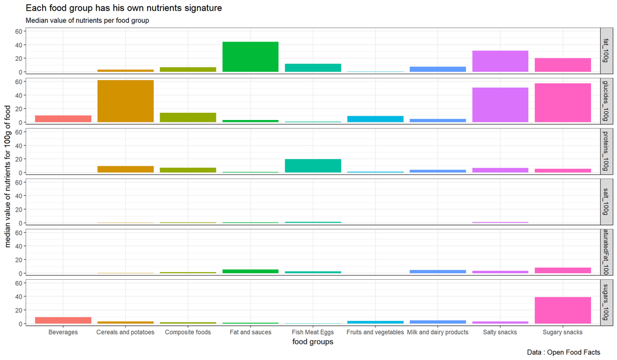

```r
# Median value of nutrients per each food group
nutriments_median_groupe1 =  openfoodfacts %>%
  filter(!is.na(groupe_1)) %>%
  filter(salt_100g <= 100, sugars_100g <= 100, glucides_100g <= 100,
         fat_100g <= 100, proteins_100g <= 100, saturatedFat_100g <= 100) %>% #remove some "easy" outliers
  select(groupe_1, salt_100g, sugars_100g, glucides_100g, fat_100g, proteins_100g, saturatedFat_100g) %>%
  gather("nutriment", "valeur", -groupe_1) %>% #to long format
  group_by(nutriment, groupe_1) %>%
  summarise(valeur_mediane = median(valeur)) %>%
  ungroup()

# Visualization
ggplot(nutriments_median_groupe1, aes(x = groupe_1, y = valeur_mediane, fill = groupe_1)) +
  geom_bar(stat = "identity") +
  ggtitle(label = "Each food group has his own nutrients signature",
          subtitle = "Median value of nutrients per food group") +
  labs(x = "food groups",
       y = "median value of nutrients for 100g of food",
       caption = "Data : Open Food Facts") +
  facet_grid(nutriment ~ .) + #multiple rows
  theme_bw() +
  theme(legend.position = "none") #no legend
```

# Decision tree

From the remark above, it seems natural to use a decision tree based on the value of nutrients. Indeed, if carbohydrates and sugars are high, it is a sugary snacks. Let’s build a decision tree (supervised classification task).

## Setting

For this tasks, one will remove the “easy” outliers from the dataset and sample it into two datasets : one for the learning task and the other for the performance measuring.

```r
# Only keeping observations where the food group is valid and removing easy outliers
openfoodfacts_ml = openfoodfacts %>%
  filter(!is.na(groupe_1)) %>%
  filter(salt_100g <= 100, sugars_100g <= 100, glucides_100g <= 100,
         fat_100g <= 100, proteins_100g <= 100, saturatedFat_100g <= 100) %>%
  select(groupe_1, salt_100g, sugars_100g, glucides_100g, fat_100g, proteins_100g, saturatedFat_100g)

# Checking that NA observations are out
colSums(is.na(openfoodfacts_ml)) %>% sort(decreasing = TRUE)
```

```
##          groupe_1         salt_100g       sugars_100g     glucides_100g
##                 0                 0                 0                 0
##          fat_100g     proteins_100g saturatedFat_100g
##                 0                 0                 0
```

```r
#Sampling : 80% for train / 20% for test
sample_size = floor(0.80 * nrow(openfoodfacts_ml))

## set the seed to make your partition reproducible
set.seed(42)
train_ind = sample(seq_len(nrow(openfoodfacts_ml)), size = sample_size)

train = openfoodfacts_ml[train_ind, ]
test = openfoodfacts_ml[-train_ind, ]

cat(sprintf("Among the %.0f observations of the database of Open Food Facts, only %.0f are useful for this methodology.\n
            \tIn the training dataset, there are %.0f observations.\n
            \tIn the test dataset, there are %.0f observation",
            nrow(openfoodfacts), nrow(openfoodfacts_ml), nrow(train), nrow(test)))
```

```
## Among the 677830 observations of the database of Open Food Facts, only 109899 are useful for this methodology.
##
##              In the training dataset, there are 87919 observations.
##
##              In the test dataset, there are 21980 observation
```

## Learning

Let’s fit the model on the training dataset :

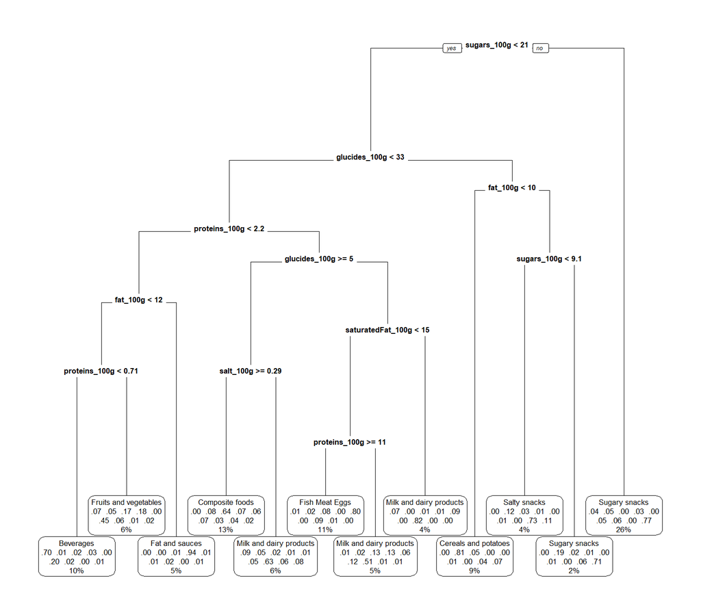

```r
# Learning phase
fit = rpart(groupe_1 ~ salt_100g + sugars_100g + glucides_100g + fat_100g + proteins_100g + saturatedFat_100g,
            data = train)

# Plot the tree
rpart.plot(fit, type = 0, box.palette = 0) #type = 0 makes it simplier ; box.palette = 0 removes colors
```

## Performance measuring

Let’s predict values on the test dataset and measure the accuracy :

```r
# Prediction
test$groupe_1_hat = predict(fit, test, type = "class")

# Confusion matrix
table(test$groupe_1_hat, test$groupe_1)
```

```
##
##                           Beverages Cereals and potatoes Composite foods
##   Beverages                    1555                   34              39
##   Cereals and potatoes            7                 1530             107
##   Composite foods                10                  210            1742
##   Fat and sauces                  2                    1              14
##   Fish Meat Eggs                 10                   56             200
##   Fruits and vegetables          93                   53             235
##   Milk and dairy products       210                   98             165
##   Salty snacks                    2                   98              26
##   Sugary snacks                 198                  343              15
##
##                           Fat and sauces Fish Meat Eggs
##   Beverages                           56              6
##   Cereals and potatoes                 8              3
##   Composite foods                    201            157
##   Fat and sauces                    1049              6
##   Fish Meat Eggs                       9           1839
##   Fruits and vegetables              229              8
##   Milk and dairy products            169            152
##   Salty snacks                         6              0
##   Sugary snacks                      150              1
##
##                           Fruits and vegetables Milk and dairy products
##   Beverages                                 462                      49
##   Cereals and potatoes                       20                       9
##   Composite foods                           194                      93
##   Fat and sauces                             16                      23
##   Fish Meat Eggs                              9                     205
##   Fruits and vegetables                     561                      90
##   Milk and dairy products                   197                    2362
##   Salty snacks                                3                       5
##   Sugary snacks                             267                     310
##
##                           Salty snacks Sugary snacks
##   Beverages                          0            13
##   Cereals and potatoes              67           171
##   Composite foods                  131            38
##   Fat and sauces                     3             4
##   Fish Meat Eggs                    29             1
##   Fruits and vegetables              8            19
##   Milk and dairy products           93           103
##   Salty snacks                     577            84
##   Sugary snacks                     56          4606
```

```r
# Accuracy of the model
accuracy = 100 * mean(test$groupe_1_hat == test$groupe_1)
sprintf("Accuracy of the model : %.2f%%.", accuracy)
```

```
## [1] "Accuracy of the model : 71.98%."
```

# Prediction on the Open Food Facts dataset

Now, the model is able to predict, with an accuracy of nearly 70%, the food group of a product given the nutrients. As the nutrients data are available on nearly 75% of the whole dataset, one can get the food group for 75% of products and not only on 20% of products.

## Prediction on the remained observations

One uses the same model.

```r
# Only keeping observations with nutrients
openfoodfacts_nutrients = openfoodfacts %>%
  filter(!is.na(salt_100g), !is.na(sugars_100g), !is.na(glucides_100g),
         !is.na(fat_100g), !is.na(proteins_100g), !is.na(saturatedFat_100g))

cat(sprintf("There are %.0f observations where the nutrients are valid, ie %.2f%% of the original data.\n",
            nrow(openfoodfacts_nutrients),
            100 * nrow(openfoodfacts_nutrients)/nrow(openfoodfacts)))
```

```
## There are 519253 observations where the nutrients are valid, ie 76.61% of the original data.
```

Let’s predict with the previous model :

```r
# Prediction
openfoodfacts_nutrients$groupe_1_hat = predict(fit, openfoodfacts_nutrients, type = "class") %>% as.character()

# If the group is given, one will keep it
openfoodfacts_nutrients$food_group = ifelse(is.na(openfoodfacts_nutrients$groupe_1), #if the group is missing
                                            openfoodfacts_nutrients$groupe_1_hat, #we use the prediction
                                            openfoodfacts_nutrients$groupe_1) #otherwise, we use the group
```

## Some analysis of the model

Is there any bias ?

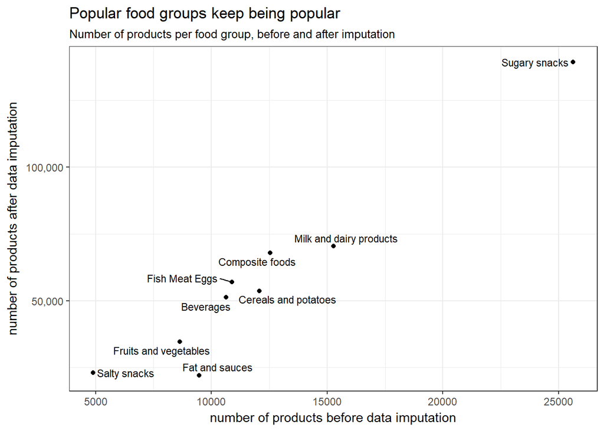

```r
# Number of products per food group if the nutrients are given
n_EAN_by_groupe1_if_nutrients = openfoodfacts_nutrients %>%
  filter(!is.na(groupe_1)) %>%
  group_by(groupe_1) %>%
  summarise(count_before = EAN %>% unique() %>% length()) %>%
  ungroup()


# Number of products per food group after data imputation
n_EAN_by_groupe1_after_imputation = openfoodfacts_nutrients %>%
  group_by(food_group) %>%
  summarise(count_after = EAN %>% unique() %>% length()) %>%
  ungroup()

# Join
n_EAN_by_groupe_1_before_after = n_EAN_by_groupe1_if_nutrients %>%
  left_join(n_EAN_by_groupe1_after_imputation, by = c("groupe_1" = "food_group"))

# Visualisation before-after
ggplot(n_EAN_by_groupe_1_before_after, aes(x = count_before, y = count_after)) +
  geom_point() +
  geom_text_repel(aes(label = groupe_1), size = 3) +
  ggtitle(label = "Popular food groups keep being popular",
          subtitle = "Number of products per food group, before and after imputation") +
  labs(x = "number of products before data imputation",
       y = "number of products after data imputation") +
  scale_y_continuous(labels = scales::comma) +
  theme_bw()
```

# Perspectives

This model is only a baseline. It relies on six nutrients and only predict the groupe_1 (and not the pnns_groups_2, which is more precise). Moreover, the model is not fine-tuned (hyper-parameters, pruning, data engineering, …) and using more features and more complex models may improve the results.

The last but not the least : we should verify that the predicted food group is coherent with the product’s name in the case where the groupe_1 was not defined previously, in order to detect any bias.

Keep free to improve the model =)